# R Notebook

############ ############ ############ ############ FONCTIONS ############ ############ ############ ############

##### DATA = Données à normaliser

##### Revoie les données normalisées

```r
Normalize_data <- function(DATA){
  res <- voom(DATA) %>% .$E
  return(res)
}
```

##### Créé une heatmap de corrélation entre les échantillons

##### DATA = Données à analyser

##### Phenotype = Tableau de données renseignant le phénotype des échantillons

##### Ne renvoie rien

```r
Make_heatmap <- function(DATA, Phenotype) {
  ann_color <- list(
    Phenotype = c(cancer = "red", healthy = "blue"))
  annotation_for_heatmap <- data.frame(Phenotype = Phenotype$Phenotype)
  rownames(annotation_for_heatmap) <- colnames(DATA)
  corr <- rcorr(as.matrix(DATA), type = "pearson")$r
  colnames(corr) <- colnames(DATA)
  heatmap <- pheatmap(corr,
                      color = colorRampPalette(brewer.pal(n = 9, name = "YlOrRd"))(100),
                      annotation_col = annotation_for_heatmap,
                      annotation_colors = ann_color,
                      legend = TRUE,
                      treeheight_row = 20,
                      fontsize = 10
  )
  return(heatmap)
}
```

##### compare l’expression génique à travers les différents phénotypes

##### DATA = Données à analyser

##### Phenotype = Tableau de données renseignant le phénotype des échantillons

##### Renvoie un tableau d’analyse de gene expression

```r
Differential_analysis <- function(DATA, Phenotype){
  design.pairs <- function(levels) {
    n <- length(levels)
    design <- matrix(0,n,choose(n,2))
    rownames(design) <- levels
    colnames(design) <- 1:choose(n,2)
    k <- 0
    for (i in 1:(n - 1))
      for (j in (i + 1):n) {
        k <- k + 1
        design[i,k] <- 1
        design[j,k] <- -1
        colnames(design)[k] <- paste(levels[i], "-", levels[j],sep = "")
      }
    design
  }
  design <- model.matrix(~0 + Phenotype$Phenotype)
  contr.matrix <- design.pairs(levels(factor(Phenotype$Phenotype)))
  colnames(design) <- rownames(contr.matrix)
  Fit <- lmFit(DATA, design) %>%
    contrasts.fit(., contr.matrix) %>%
    eBayes(., trend = TRUE)

  FitList <- list()
  for (i in 1:ncol(contr.matrix)) {
    FitList[[i]] <- topTable(Fit, coef = i, adjust.method = "BH", number = nrow(DATA)) %>%
      mutate(ID = rownames(.))

    message(paste0(i, " done"))

  }
  names(FitList) <- colnames(contr.matrix)
  return(FitList[[1]])
}
```

############ ############ ############ ############ A COMPLETER ############ ############ ############ ############

# A faire

##### Tableau des phénotypes

```r
data_norm <- Normalize_data(Data_combined)

example_de_tableau_de_phenotype
```

| Sample | Phenotype |
| --- | --- |
| Sample_1 | heatlhy |
| Sample_2 | heatlhy |
| Sample_3 | heatlhy |
| Sample_4 | cancer |
| Sample_5 | cancer |
| Sample_6 | cancer |
| Sample_7 | treated |
| Sample_8 | treated |
| Sample_9 | treated |

```r
phenotype = c(rep("cancer", each = 21), rep("healthy", each = 2))

Tableau_des_phenotypes <- data.frame("Sample" = colnames(Data_combined), "Phenotype" = phenotype)
```

# A faire

##### Heatmap

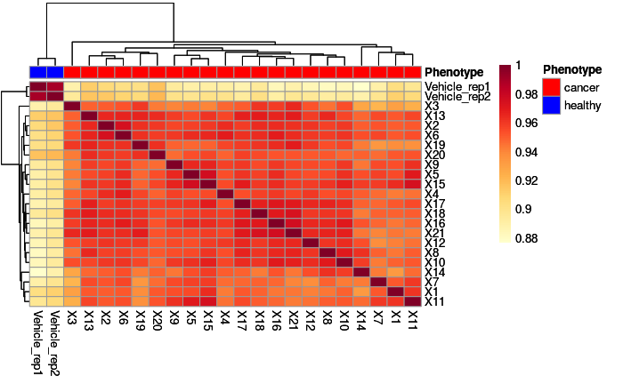

```r
Make_heatmap(data_norm, Tableau_des_phenotypes)
```

# A faire

##### Analyse différentielle d’expression

```r
Analysis <- Differential_analysis(data_norm, Tableau_des_phenotypes)
```

```
1 done
```

# A faire

##### Liste des gènes dont la différence d’expression est la plus significative (p.value < 0.05)

```r
genes <- c()
liste_genes <- Analysis

for (i in 1:length(liste_genes$logFC)){
  if (liste_genes[i,4] < 0.05){
     genes <- c(genes,(liste_genes[i,7]))
  }
}




noms_genes <- liste_genes[liste_genes$P.Value < 0.05, ]
```

# A faire

##### Lister les gènes sous exprimés dans les échantillons sains

##### TP53 est-il différemment exprimé dans les échantillons malades ?

##### CEBPA ?

```r
noms_genes_plus <- noms_genes[noms_genes$logFC > 0,7]

Analysis[Analysis$ID=="TP53",]
```

|  | logFC | AveExpr | t | P.Value | adj.P.Val | B | ID |
| --- | --- | --- | --- | --- | --- | --- | --- |
| TP53 | -0.5987215 | 6.575222 | -1.023792 | 0.3155053 | 0.5918283 | -6.196977 | TP53 |

```r
#Non, P Value > 0.05

Analysis[Analysis$ID=="CEBPA",]
```

|  | logFC | AveExpr | t | P.Value | adj.P.Val | B | ID |
| --- | --- | --- | --- | --- | --- | --- | --- |
| CEBPA | 4.186709 | 3.887708 | 5.614767 | 7.043561e-06 | 0.0001365937 | 3.723885 | CEBPA |

```r
#Oui et P Value < 0.05 : + exprimé dans le cas du cancer
```

# A faire

##### Lister les 100 gènes les plus différemment exprimés

```r
tri <- rev(order(abs(noms_genes$logFC)))
les_cents <- tri[0:100]
cent_id <- noms_genes[les_cents,]
```

============================================================== Session 24.03 ======================================================================

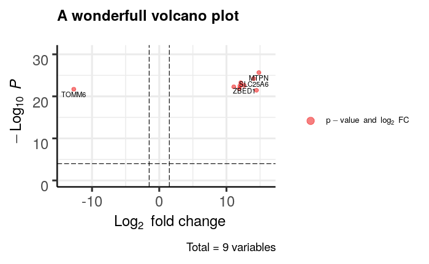

```r
Make_a_volcano_plot <- function(DATA_analysed, List_of_genes, x_axis, y_axis, title){
  EnhancedVolcano(
  toptable = DATA_analysed,
  lab = List_of_genes,
  x = x_axis,
  y = y_axis,
  FCcutoff = 1.5,
  pCutoff = 0.0001,
  title = title,
  subtitle = NA,
  legendPosition = "right",
  subtitleLabSize = 0,
  legendLabSize = 10
)
}

Differencial_gene_expression_analysis <- read.csv("../Data/Differencial_gene_expression_analysis.csv")

Make_a_volcano_plot(Differencial_gene_expression_analysis, Differencial_gene_expression_analysis$Gene_names, "Column_B", "Column_D", "A wonderfull volcano plot")
```

```r
NA
NA
```

```r
Make_a_gene_ontology_analysis <- function(Gene_to_analyze){
  test_enrich <- enrichGO(Gene_to_analyze, OrgDb = "org.Hs.eg.db", ont = "BP", pAdjustMethod = "none", keyType = "SYMBOL")
  return(test_enrich)
}
```

# A faire

##### Faire un volcanoplot de l’analyse d’expression génique

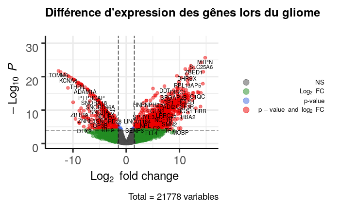

```r
Make_a_volcano_plot(Analysis, rownames(Analysis), "logFC", "P.Value", "Différence d'expression des gênes lors du gliome")
```

# Try to explain the figure. You can check the data results to help your analysis.

Ce document est un volcano plot décrivant la différence d’expression des gènes dans le cas du gliome. On considère en abscisse le fold change : la différence d’expression du gène en question, et en ordonnée la P.Value, mesurant la significativé des résultats obtenus. On observe qu’il y a des gènes significativement différemment exprimés. Cependant, on voit également qu’il y a plus de gènes significativement sur-exprimés que sous-exprimés. Le Log FC des gènes étudiés est compris entre -15 et 15. Nous avons considéré un résultat significatif si sa P.Value est strictement inférieur à 0.0001, soit -log10P strictement supérieur à 4. De la même manière, nous n’avons étudié que les résultats dont la valeur absolue de Log2 fold change est supérieure à 1.5.